# Draft Exploratory Analysis

*ECNS 560 Term Project: Bison Population Kyle Froisland and Saki*

*Topic:* American Buffalo (Bison) Population Levels from Early 2000’s to Now

*Potential Research Questions:* 1. How much has Bison population changed in the US over time? 2. How much has Bison population changed in different parts of the US? 3. How does Bison health vary across habitats/ranges? 4. Do variations in state/national park laws and regulations impact Bison population levels? a. Examples: availability of hunting tags, zoning/homesteading or prevalence of private ranches under/over a certain size, regulations on meat/pelt sales (would need to locate data for specific “X” ideas) 5. Do variations in state/national park laws and regulations impact average Bison population? 6. How do changes in population impact hunting license spending?

*Motivation:* Bison population reached near extinction (estimates generally say a few hundred bison) during the late 19th century, but had a miraculous comeback in the early to middle 20th century. However, the health and sustainability of bison populations is still an issue. Factors such as the opportunity cost of agricultural farming and cattle ranching loom and tend to crowd out bison domestication, and policies such as homesteading and urban expansion encroach on the grazing land of bison. Bison, being the national mammal of the U.S., play a culturally significant part in the history of the United States as well as the culture of native populations prior to the establishment of the United States. Thus, conservation efforts, regulations, or subsidies/incentives for private herds and domestication may be worth consideration by policy makers or conservation groups.

*Data:* 1. Bison population numbers by county from ArcGIS, Center of Excellence for Bison Studies, South Dakota State: Bison by the Numbers (arcgis.com) a. Years covered: 2002, 2007, 2012, 2017 b. Variables: State, County, Population (by year), Number of Operations (by year)

2. United States Geological Survey (USGS) Bison Range and Bison Habitat Maps: American Bison (Bison bison) mBISOx_CONUS_2001v1 Range Map - ScienceBase-Catalog and American Bison (Bison bison) mBISOx_CONUS_2001v1 Habitat Map - ScienceBase-Catalog
1. Provides spatial data on ranges and habitats
3. Hunting License Data By State: https://us-east-1.quicksight.aws.amazon.com/sn/accounts/329180516311/dashboards/48b2aa9c-43a9-4ea6-887e-5465bd70140b?directory_alias=tracs-quicksight
1. Years Covered: 1958 - 2024
2. Variables: State, Year, Paid License Holders, Resident and Non-Resident licenses, Cost of Hunting Licenses

*Data Processing:* In order to analyze this data, we first created a tidy version of the Bison Population data. In order to do this we pivoted the data set from the columns containing population in each year and created a “year” column and a “population” column in their place. Once this was complete, we needed to string clean these columns as each observation included “bison_census” before the year instead of containing only the year. Then, we needed to create a new variable in order to get state-by state data as opposed to county-by-county. While we lost some details during this process, it allowed us to create a new dataset that would merge cleanly with our hunting data (as the hunting data contains only state level numbers).

Next, we cleaned the hunting data, making sure that we rename columns so that they will match with the population data and that we limited the years to only those years that also match the population data (ie, 2002, 2007, 2012, and 2017). Additionally, some years were inputted as strings across the data sets while others were numeric, so we converted all years to numeric format in order to facilitate merging in the next step.

Finally, we merged the two data sets by their state and year variables in order to create a final dataframe for visualization and analysis. To do this we used a left join method that would join the hunting data to the original population data. The unit of analysis for this dataset is population and hunting data by state and by year, which we chose because we were constrained by the hunting data. Although we lost some details from the population data, state and year is an appropriate level of analysis because, as we see in the “ranges” shapefile, most Bison populations are concentrated in herds that graze in very concentrated and protected areas. Thus, additional details with regard to county level population would not change our results significantly and can be deduced from our range spatial data if necessary.

*Visualizations:* Our first visualization sought to explore the Bison population trends of some major states over time. The following displays trends among four major western United States states (Montana, Wyoming, North Dakota, and South Dakota):

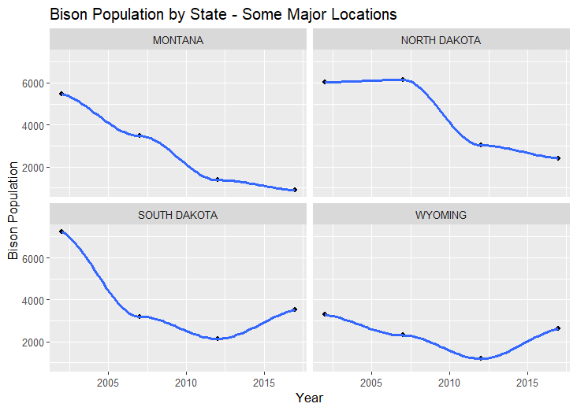

What we see from the initial visualization is that there seems to be a general downward trend in Bison population from 2002 to 2017, but that there is no obvious trend between sates in between. In other words, while all states ultimately have lower population numbers in 2017 than in 2002, there is fluctuation in between those years in which some states saw relatively steady decline (such as Montana), others saw sharp drops amidst periods of steady decline (such as North Dakota), and some even saw short periods of population growth (such as South Dakota and Wyoming).

After realizing that there is some variety in the details of population growth or decline across states, we sought to confirm our suspicion that the overall population trend is negative. What we see in the following graph is a confirmation of that suspicion, where population sees a strong downward trend across the Great Plains:

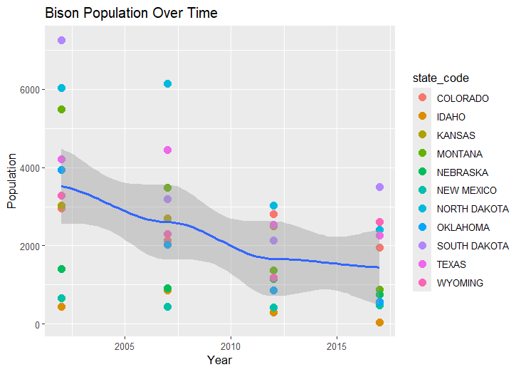

As a side note, our decision to restrict our focus to the Great Plains was based off of our spatial data which indicates to us that the majority of Bison herds are concentrated in these states, as shows in the following image:

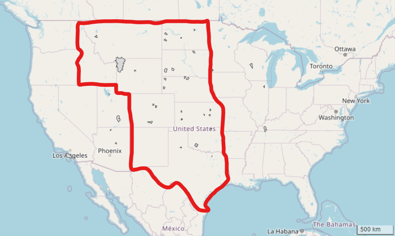

Once we confirmed that population is indeed declining, we started exploring fluctuations in hunting license numbers as a possible correlate. The following graph shows the number of hunting licenses across the same years and the same states as our previous visual:

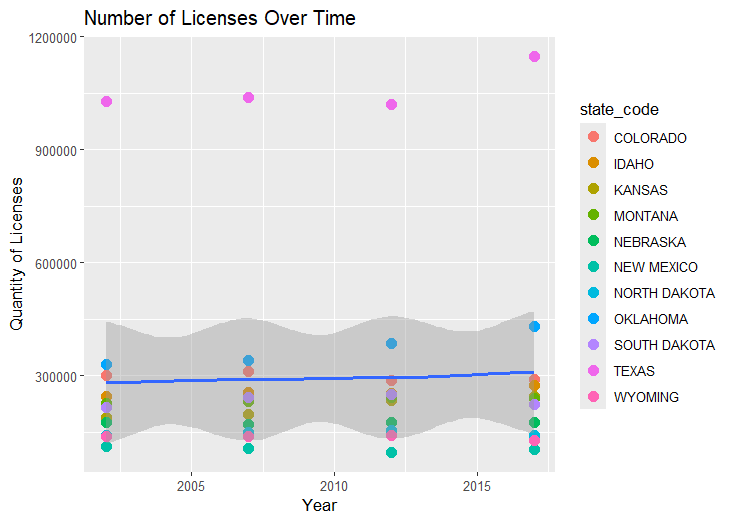

From this graph, we do not see any obvious trends in hunting licenses over time across the Great Plains. The following graph confirms our suspician that there is not an obvious correlation between hunting licenses and Bison population overall (population fluctuates in both directions as the number of hunting licenses increases):

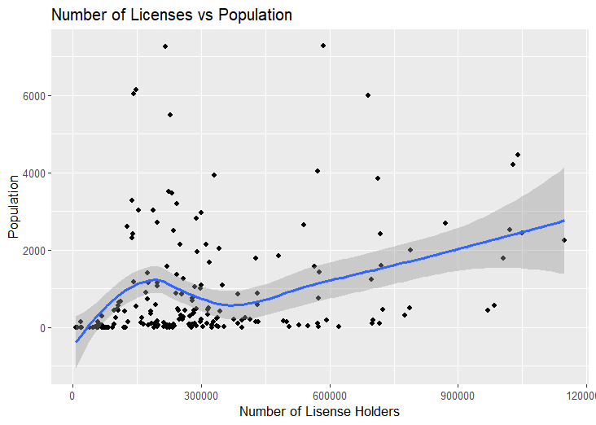

Although there is not an obvious and immediate relationship with our initial visualizations, it is still possible that we could find a relationship if we can find quick changes in the number of licenses in certain areas to exploit. Thus, in the following graph we explored the number of licenses in various states to see if any saw rapid increases or decreases in hunting licenses:

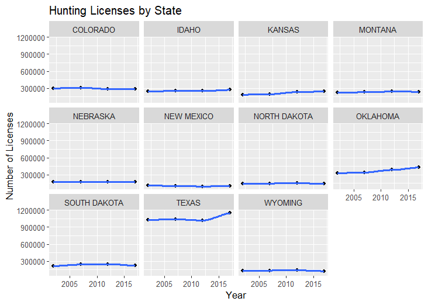

From this visualization, we see that most states do not have significant fluctuations in their number of hunting licenses. However, Texas saw an upward trend in licenses from 2012 to 2017. The following plot explores the relationship between the increase in hunting licenses and population changes in Texas:

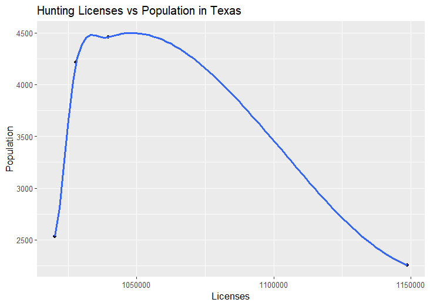

The data does not seem to indicate a linear relationship. This could be due to a variety of reasons, including the possibility that an increase in the number of hunting licenses does not necessarily mean that there is an increase in the amount of Bison hunting (as the licenses could be for any number of animals).

In further exploration, other indicators such as weather or local policy differences may be more useful indicators of population levels.